# Project on Plant Seedlings Classification using CNN By JATINDER ACHARYA

Description Background and Context - Jatinder Acharya

In recent times, the field of agriculture has been in urgent need of modernizing, since the amount of manual work people need to put in to check if plants are growing correctly is still highly extensive. Despite several advances in agricultural technology, people working in the agricultural industry still need to have the ability to sort and recognize different plants and weeds, which takes a lot of time and effort in the long term.

The potential is ripe for this trillion-dollar industry to be greatly impacted by technological innovations that cut down on the requirement for manual labor, and this is where Artificial Intelligence can benefit the workers in this field, as the time and energy required to identify plant seedlings will be greatly shortened by the use of AI and Deep Learning. The ability to do so far more efficiently and even more effectively than experienced manual labor could lead to better crop yields, the freeing up of human involvement for higher-order agricultural decision making, and in the long term will result in more sustainable environmental practices in agriculture as well.

Objective

The Aarhus University Signal Processing group, in collaboration with the University of Southern Denmark, has provided the data containing images of unique plants belonging to 12 different species. You being a data scientist, need to build a Convolutional Neural Network model which would classify the plant seedlings into their respective 12 categories.

Data Description

This dataset contains images of unique plants belonging to 12 different species. The data file names are: images.npy Label.csv Due to the large volume of data, the images were converted to numpy arrays and stored in images.npy file and the corresponding labels are also put into Labels.csv so that you can work on the data/project seamlessly without having to worry about the high data volume. The goal of the project is to create a classifier capable of determining a plant's species from an image. List of Plant species

Black-grass Charlock Cleavers Common Chickweed Common Wheat Fat Hen Loose Silky-bent Maize Scentless Mayweed Shepherds Purse Small-flowered Cranesbill Sugar beet Guide to solve the project seamlessly

**Mounting Google drive for Colab Use**

```python
from google.colab import drive
drive.mount('/content/drive/')

# import os
# os.chdir('drive/MyDrive/CNN_Project')
# # !ls "/content/drive/My Drive"
```

Changing directory to fetch project files

```python
import os
os.chdir('drive/MyDrive/CNN_Project/')
```

**Importing necessary Libraries**

```python
import pandas as pd, numpy as np, matplotlib.pyplot as plt
import seaborn as sns
from matplotlib import pyplot
%matplotlib inline

import warnings
from sklearn.exceptions import DataConversionWarning
warnings.filterwarnings(action='ignore', category=DataConversionWarning)

random_state = 42
import random
random.seed(random_state)

batch_size = 32
epochs = 500


# Create features and labels
from tensorflow.keras.applications.mobilenet import preprocess_input
import cv2
```

```python
!ls
```

```
classifier_color.h5	     classifier_grayscale_weights.h5  images.npy
classifier_color_weights.h5  classifier.h5		      Labels.csv
classifier_grayscale.h5      classifier_weights.h5
```

**Loading the Images numpy array into a data array**

```python
np_load_old = np.load

# # modify the default parameters of np.load
np.load = lambda *a,**k: np_load_old(*a, allow_pickle = True, **k)

data = np.load('images.npy')
```

```python
# data
```

Checking the shape of the Images array

```python
data.shape
```

```
(4750, 128, 128, 3)
```

**Loading labels csv file to Pandas DF**

```python
ylabels = pd.read_csv('Labels.csv')
ylabels.head()
```

|  | Label |
| --- | --- |
| 0 | Small-flowered Cranesbill |
| 1 | Small-flowered Cranesbill |
| 2 | Small-flowered Cranesbill |
| 3 | Small-flowered Cranesbill |
| 4 | Small-flowered Cranesbill |

**Getting all unique different categories into a list**

```python
categ = ['Black-grass', 'Charlock', 'Cleavers', 'Common Chickweed', 'Common wheat', 'Fat Hen', 'Loose Silky-bent',
              'Maize', 'Scentless Mayweed', 'Shepherds Purse', 'Small-flowered Cranesbill', 'Sugar beet']
num_categ = len(categ)
num_categ
```

```
12
```

**Observation:**

- Total number of plant categories are 12 ie., o/p preds should be 12
- We have a total of 4750 plant images
- Each image is of shape 128 X 128
- As the number of channels is 3, images are in RGB (Red, Blue, Green)

**Plant Categories Distribution**

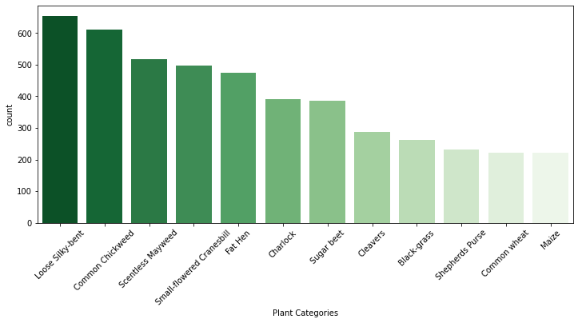

```python
plt.rcParams["figure.figsize"] = (12,5)
sns.countplot(x=ylabels.iloc[:,-1],order = ylabels['Label'].value_counts().index, palette='Greens_r')
plt.xlabel('Plant Categories')
plt.xticks(rotation=45)
```

**Observation:**

- "Loose Silky bent" plant samples are more compared to other categories
- Least plant samples are for "Common Wheat", "Maize"

**Plotting differnt plant categories in 12X12 grid**

```python
#Importing ImageGrid to plot the plant sample images
from mpl_toolkits.axes_grid1 import ImageGrid
```

[figure not shown]

```python
#defining a figure of size 12X12
fig = plt.figure(1, figsize=(num_categ, num_categ))
grid = ImageGrid(fig, 111, nrows_ncols=(num_categ, num_categ), axes_pad=0.05)
i = 0
index = ylabels.index

#Plottting 12 images from each plant category
for category_id, category in enumerate(categ):
  condition = ylabels["Label"] == category
  plant_indices = index[condition].tolist()
  for j in range(0,12):
      ax = grid[i]
      ax.imshow(data[plant_indices[j]])
      ax.axis('off')
      if i % num_categ == num_categ - 1:
        #printing the names for each caterogy
        ax.text(200, 70, category, verticalalignment='center')
      i += 1
plt.show();
```

**Data Preprocessing**

```python
#Importing cv2_imshow for displaying images
from google.colab.patches import cv2_imshow
```

**Resizing and applying Gaussian Blur on a single image and plotting**

```
Resized to 50% and applied Gaussian Blurring with kernel size 3X3
```

```
Original Image of size 128X128
```

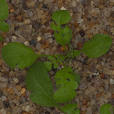

```python
# Resizing the image size to half ie., from 128X128 to 64X64
img = cv2.resize(data[1000],None,fx=0.50,fy=0.50)

#Applying Gaussian Blur
img_g = cv2.GaussianBlur(img,(3,3),0)

#Displaying preprocessed and original images
print("Resized to 50% and applied Gaussian Blurring with kernel size 3X3")
cv2_imshow(img_g)
print('\n')
print("Original Image of size 128X128")
cv2_imshow(data[1000])
```

**Converting to HSV and applying mask for the background and focusing only on plant**

```python
# Convert to HSV image
hsvImg = cv2.cvtColor(img_g, cv2.COLOR_BGR2HSV)
cv2_imshow(hsvImg)
```

[output not shown]

```python
# Create mask (parameters - green color range)
lower_green = (25, 40, 50)
upper_green = (75, 255, 255)
mask = cv2.inRange(hsvImg, lower_green, upper_green)
kernel = cv2.getStructuringElement(cv2.MORPH_ELLIPSE, (11, 11))
mask = cv2.morphologyEx(mask, cv2.MORPH_CLOSE, kernel)

# Create bool mask
bMask = mask > 0

# Apply the mask
clearImg = np.zeros_like(img, np.uint8)  # Create empty image
clearImg[bMask] = img[bMask]  # Apply boolean mask to the origin image

#Masked Image after removing the background
cv2_imshow(clearImg)
```

[output not shown]

**Applying Resize, Gaussian Blurr and Masking on All Images**

```python
data_copy = data.copy()
```

```python
lower_green = (25, 40, 50)
upper_green = (75, 255, 255)
kernel = cv2.getStructuringElement(cv2.MORPH_ELLIPSE, (11, 11))
preprocessed_data_color = []

for img in data:
  resize_img = cv2.resize(img,None,fx=0.50,fy=0.50)
  Gblur_img = cv2.GaussianBlur(resize_img,(3,3),0)
  hsv_img = cv2.cvtColor(Gblur_img, cv2.COLOR_BGR2HSV)
  mask = cv2.inRange(hsv_img, lower_green, upper_green)
  mask = cv2.morphologyEx(mask, cv2.MORPH_CLOSE, kernel)
  bMask = mask > 0
  clearImg = np.zeros_like(resize_img, np.uint8)  # Create empty image
  clearImg[bMask] = resize_img[bMask]  # Apply boolean mask to the original image
  # clearImg1 = cv2.cvtColor(clearImg,cv2.COLOR_BGR2GRAY)

  preprocessed_data_color.append(clearImg)

#Preprocessed all plant images
preprocessed_data_color = np.asarray(preprocessed_data_color)
```

**Visualizing the preprocessed color plant images**

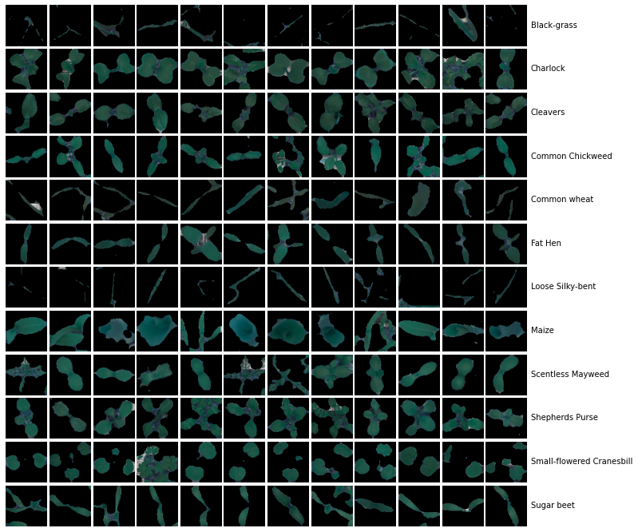

```python
from mpl_toolkits.axes_grid1 import ImageGrid

fig = plt.figure(1, figsize=(num_categ, num_categ))
grid = ImageGrid(fig, 111, nrows_ncols=(num_categ, num_categ), axes_pad=0.05)
i = 0
index = ylabels.index

for category_id, category in enumerate(categ):
  condition = ylabels["Label"] == category
  plant_indices = index[condition].tolist()
  for j in range(0,12):
      ax = grid[i]
      # img = read_img(filepath, (224, 224))
      # ax.imshow(img / 255.)
      ax.imshow(preprocessed_data_color[plant_indices[j]]/255.)
      # ax[i].set_title(ylabels.iloc[i].to_list(),fontsize=7,rotation=45)
      ax.axis('off')
      if i % num_categ == num_categ - 1:
          ax.text(70, 30, category, verticalalignment='center')
      i += 1
plt.show();
```

```python
preprocessed_data_color.shape
```

```
(4750, 64, 64, 3)
```

**Converting all color images to Grayscale images**

```python
preprocessed_data_gs = []
for img in preprocessed_data_color:
  gi = cv2.cvtColor(img, cv2.COLOR_BGR2GRAY)
  preprocessed_data_gs.append(gi)

preprocessed_data_gs = np.asarray(preprocessed_data_gs)
```

```python
preprocessed_data_gs.shape
```

```
(4750, 64, 64)
```

**Visualizing the preprocessed Grayscale plant images**

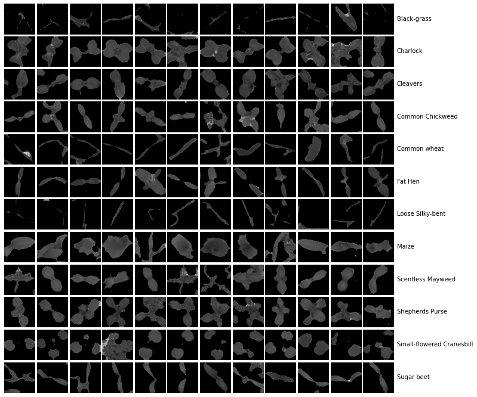

```python
fig = plt.figure(1, figsize=(num_categ, num_categ))
grid = ImageGrid(fig, 111, nrows_ncols=(num_categ, num_categ), axes_pad=0.05)
i = 0
index = ylabels.index

for category_id, category in enumerate(categ):
  condition = ylabels["Label"] == category
  plant_indices = index[condition].tolist()
  for j in range(0,12):
      ax = grid[i]
      # img = read_img(filepath, (224, 224))
      # ax.imshow(img / 255.)
      ax.imshow(preprocessed_data_gs[plant_indices[j]],cmap='gray',vmin=0, vmax=255)
      # ax[i].set_title(ylabels.iloc[i].to_list(),fontsize=7,rotation=45)
      ax.axis('off')
      if i % num_categ == num_categ - 1:
          ax.text(70, 30, category, verticalalignment='center')
      i += 1
plt.show();
```

**Converting Grayscale to Edge images using Sobel and Laplacian**

```python
sobel = cv2.Sobel(preprocessed_data_gs[0]*255, cv2.CV_64F,1,1,ksize=3)
laplacian = cv2.Laplacian(preprocessed_data_gs[0]*255, cv2.CV_64F)
cv2_imshow(sobel)
print("\n")
cv2_imshow(laplacian)
```

[output not shown]

```python
preprocessed_data_Edge_Lap = []
for img in preprocessed_data_gs:
  egi = cv2.Laplacian(img*255, cv2.CV_64F)
  preprocessed_data_Edge_Lap.append(egi)

preprocessed_data_Edge_Lap = np.asarray(preprocessed_data_Edge_Lap)
```

```python
preprocessed_data_Edge_Lap.shape
```

```
(4750, 64, 64)
```

**Visualizing the preprocessed Edge plant images**

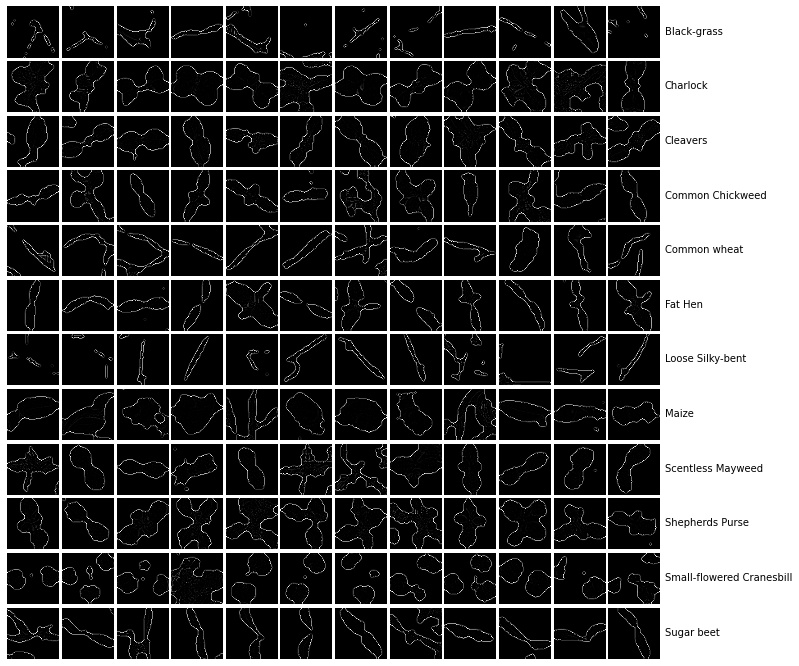

```python
fig = plt.figure(1, figsize=(num_categ, num_categ))
grid = ImageGrid(fig, 111, nrows_ncols=(num_categ, num_categ), axes_pad=0.05)
i = 0
index = ylabels.index

for category_id, category in enumerate(categ):
  condition = ylabels["Label"] == category
  plant_indices = index[condition].tolist()
  for j in range(0,12):
      ax = grid[i]
      # img = read_img(filepath, (224, 224))
      # ax.imshow(img / 255.)
      ax.imshow(preprocessed_data_Edge_Lap[plant_indices[j]],cmap='gray',vmin=0, vmax=255)
      # ax[i].set_title(ylabels.iloc[i].to_list(),fontsize=7,rotation=45)
      ax.axis('off')
      if i % num_categ == num_categ - 1:
          ax.text(70, 30, category, verticalalignment='center')
      i += 1
plt.show();
```

**Normalization for Images**

```python
preprocessed_data_gs = preprocessed_data_gs / 255.
preprocessed_data_color = preprocessed_data_color / 255.
preprocessed_data_Edge_Lap = preprocessed_data_Edge_Lap / 255.
```

**Label Encoding and One-Hot encoding for Plant categories**

```python
ylabels['Label'] = ylabels['Label'].astype('category')
ylabels['Label'] = ylabels['Label'].cat.codes
ylabels.value_counts()
```

```
Label
6        654
3        611
8        516
10       496
5        475
1        390
11       385
2        287
0        263
9        231
7        221
4        221
dtype: int64
```

```python
from tensorflow.keras.utils import to_categorical

ylabels = to_categorical(ylabels, num_classes=12)

print("Shape of y_train:", ylabels.shape)
print("One value of y_train:", ylabels[0])
```

```
Shape of y_train: (4750, 12)
One value of y_train: [0. 0. 0. 0. 0. 0. 0. 0. 0. 0. 1. 0.]
```

## **Try 1 --> Build CNN for preprocessed color Images**

**Split the dataset into training, testing, and validation set**

```python
from sklearn.model_selection import train_test_split

val_split = 0.25
#1st split into train and test
X_train, X_test1, y_train, y_test1 = train_test_split(preprocessed_data_color, ylabels, test_size=0.30, stratify=ylabels,random_state = random_state)
#for my color image purpose and individual image pred.
X_train_color, X_test1_color, y_train_color, y_test1_color = train_test_split(data, ylabels, test_size=0.30, stratify=ylabels,random_state = random_state)
#2nd split into val and test
X_val, X_test, y_val, y_test = train_test_split(X_test1, y_test1, test_size=0.50, stratify=y_test1,random_state = random_state)
#for my color image purpose and individual image pred.
X_val_color, X_test_color, y_val_color, y_test_color = train_test_split(X_test1_color, y_test1, test_size=0.50, stratify=y_test1,random_state = random_state)

X = np.concatenate((X_train, X_test1))
y = np.concatenate((y_train, y_test1))
```

Printing the shapes for all data splits

```python
print("X_train shape: ", X_train.shape)
print("y_train shape: ", y_train.shape)
print("X_val shape: ", X_val.shape)
print("y_val shape: ", y_val.shape)
print("X_test shape: ", X_test.shape)
print("y_test shape: ", y_test.shape)
print("X shape: ", X.shape)
print("y shape: ", y.shape)
```

```
X_train shape:  (3325, 64, 64, 3)
y_train shape:  (3325, 12)
X_val shape:  (712, 64, 64, 3)
y_val shape:  (712, 12)
X_test shape:  (713, 64, 64, 3)
y_test shape:  (713, 12)
X shape:  (4750, 64, 64, 3)
y shape:  (4750, 12)
```

**Observation:**

- X_train has 3325 plant images
- X_val has 712 plant images
- X_test has 713 plant images
- Plan images are in 64X64 shape with color channel

**Reshaping data into shapes compatible with Keras models**

```python
X_train = X_train.reshape(X_train.shape[0], 64, 64, 3)
X_val = X_val.reshape(X_val.shape[0], 64, 64, 3)
X_test = X_test.reshape(X_test.shape[0], 64, 64, 3)
```

Converting type to float

```python
X_train = X_train.astype('float32')
X_test = X_test.astype('float32')
X_val = X_val.astype('float32')
```

**Using ImageDataGenerator for common data augmentation techniques**

```python
from keras.preprocessing.image import ImageDataGenerator

train_datagen = ImageDataGenerator(shear_range = 0.2,rotation_range=180,  # randomly rotate images in the range
        zoom_range = 0.1, # Randomly zoom image
        width_shift_range=0.1,  # randomly shift images horizontally
        height_shift_range=0.1,  # randomly shift images vertically
        horizontal_flip=True,  # randomly flip images horizontally
        vertical_flip=True  # randomly flip images vertically
    )


# test_val_datagen = ImageDataGenerator(rescale = 1./255)
```

```python
training_set = train_datagen.flow(X_train,y_train,batch_size=32,seed=random_state,shuffle=True)
# val_set = test_val_datagen.flow(X_val,y_val,batch_size=32,seed=random_state,shuffle=True)
# test_set = test_val_datagen.flow(X_test,y_test,batch_size=32,seed=random_state,shuffle=True)
```

**Importing required libraries for CNN**

```python
import tensorflow as tf
from keras import layers
from tensorflow.keras.models import Sequential          # Sequential groups a linear stack of layers into a tf.keras.Model.
from tensorflow.keras.layers import Conv2D              # This layer creates a convolution kernel that is convolved with the layer input to produce a tensor of outputs.
from tensorflow.keras.layers import MaxPooling2D        # Max pooling operation for 2D spatial data.
from tensorflow.keras.layers import Flatten             # Flattens the input. Does not affect the batch size.
from tensorflow.keras.layers import Dense, Dropout      # Dropout: Applies Dropout to the input.
from tensorflow.keras import callbacks
from tensorflow.keras.callbacks import EarlyStopping     # Dense: Just your regular densely-connected NN layer.
from tensorflow.keras import optimizers
```

**Creating a CNN model containing multiple layers for image processing and dense layer for classification**

CNN Model layers:

- Convolutional input layer, 32 feature maps with a size of 3X3 and a * rectifier activation function
- Batch Normalization
- Max Pool layer with size 2×2 and a stride of 2
- Convolutional layer, 64 feature maps with a size of 3X3 and a rectifier activation function.
- Batch Normalization
- Max Pool layer with size 2×2 and a stride of 2
- Convolutional layer, 64 feature maps with a size of 3X3 and a rectifier activation function.
- Batch Normalization
- Max Pool layer with size 2×2 and a stride of 2
- Flatten layer
- Fully connected or Dense layers (with 512 and 128 neurons) with Relu Act.
- Dropout layer to reduce overfitting or for regularization
- O/p layer with Softwax fun. to detect multiple categories

```python
# Initialising the CNN classifier
classifier = Sequential()

# Add a Convolution layer with 32 kernels of 3X3 shape with activation function ReLU
classifier.add(Conv2D(32, (3, 3), input_shape = (64, 64, 3), activation = 'relu', padding = 'same'))
#Adding Batch Normalization
classifier.add(layers.BatchNormalization())
# Add a Max Pooling layer of size 2X2
classifier.add(MaxPooling2D(pool_size = (2, 2),strides=2))


# Add another Convolution layer with 32 kernels of 3X3 shape with activation function ReLU
classifier.add(Conv2D(64, (3, 3), activation = 'relu', padding = 'same'))
classifier.add(layers.BatchNormalization())
classifier.add(MaxPooling2D(pool_size = (2, 2),strides=2))

# Add another Convolution layer with 32 kernels of 3X3 shape with activation function ReLU
classifier.add(Conv2D(64, (3, 3), activation = 'relu', padding = 'valid')) #no Padding
classifier.add(layers.BatchNormalization())
classifier.add(MaxPooling2D(pool_size = (2, 2),strides=2))


# Flattening the layer before fully connected layers
classifier.add(Flatten())

# Adding a fully connected layer with 512 neurons
classifier.add(layers.BatchNormalization())
classifier.add(Dense(units = 512, activation = 'relu'))

# Adding dropout with probability 0.2
classifier.add(Dropout(0.2))


# Adding a fully connected layer with 128 neurons
classifier.add(layers.BatchNormalization())
classifier.add(Dense(units = 128, activation = 'relu'))
classifier.add(Dropout(0.2))


# The final output layer with 10 neurons to predict the categorical classifcation
classifier.add(Dense(units = 12, activation = 'softmax'))
```

**Using Adam Optimizer and Categorical cross entropy as loss fun. and metrics improvement is Accuracy**

```python
# initiate Adam optimizer
adam_opt = optimizers.Adam(learning_rate=0.001, beta_1=0.9, beta_2=0.999, epsilon=1e-08)
classifier.compile(optimizer = adam_opt, loss = 'categorical_crossentropy', metrics = ['accuracy'])
```

**Printing Model Summary**

```python
classifier.summary()
```

```
Model: "sequential"
_________________________________________________________________
Layer (type)                 Output Shape              Param #
=================================================================
conv2d (Conv2D)              (None, 64, 64, 32)        896
_________________________________________________________________
batch_normalization (BatchNo (None, 64, 64, 32)        128
_________________________________________________________________
max_pooling2d (MaxPooling2D) (None, 32, 32, 32)        0
_________________________________________________________________
conv2d_1 (Conv2D)            (None, 32, 32, 64)        18496
_________________________________________________________________
batch_normalization_1 (Batch (None, 32, 32, 64)        256
_________________________________________________________________
max_pooling2d_1 (MaxPooling2 (None, 16, 16, 64)        0
_________________________________________________________________
conv2d_2 (Conv2D)            (None, 14, 14, 64)        36928
_________________________________________________________________
batch_normalization_2 (Batch (None, 14, 14, 64)        256
_________________________________________________________________
max_pooling2d_2 (MaxPooling2 (None, 7, 7, 64)          0
_________________________________________________________________
flatten (Flatten)            (None, 3136)              0
_________________________________________________________________
batch_normalization_3 (Batch (None, 3136)              12544
_________________________________________________________________
dense (Dense)                (None, 512)               1606144
_________________________________________________________________
dropout (Dropout)            (None, 512)               0
_________________________________________________________________
batch_normalization_4 (Batch (None, 512)               2048
_________________________________________________________________
dense_1 (Dense)              (None, 128)               65664
_________________________________________________________________
dropout_1 (Dropout)          (None, 128)               0
_________________________________________________________________
dense_2 (Dense)              (None, 12)                1548
=================================================================
Total params: 1,744,908
Trainable params: 1,737,292
Non-trainable params: 7,616
_________________________________________________________________
```

**EarlyStopping**

```python
callback_es = tf.keras.callbacks.EarlyStopping(monitor='val_accuracy', patience=20, min_delta=0.0001, restore_best_weights=True)
```

**Fitting the Classifier for Training set and validating for Validation set**

```python
batch_size = 32
epochs = 500
```

**Model Fitting**

```python
model1 = classifier.fit(training_set,
               batch_size=batch_size,
               epochs=epochs,
               validation_data = (X_val,y_val),
               shuffle=True,
               callbacks = [callback_es])
```

**Evaluating on Test data**

```python
classifier.evaluate(X_test,y_test)
```

```
[0.2278221994638443, 0.9186535477638245]
```

**Best Model accuracy which has least loss**

```python
best_model_accuracy = model1.history['accuracy'][np.argmin(model1.history['loss'])]
best_model_accuracy
```

```
0.9145864844322205
```

**Observation:**

**Printing out the Confusion Matrix**

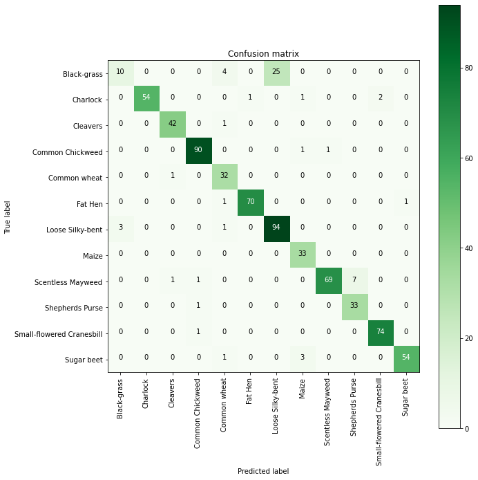

```python
from sklearn.metrics import confusion_matrix
import itertools

def plot_confusion_matrix(cm, classes,
                          normalize=False,
                          title='Confusion matrix',
                          cmap=plt.cm.Greens):

    fig = plt.figure(figsize=(10,10))
    plt.imshow(cm, interpolation='nearest', cmap=cmap)
    plt.title(title)
    plt.colorbar()
    tick_marks = np.arange(len(classes))
    plt.xticks(tick_marks, classes, rotation=90)
    plt.yticks(tick_marks, classes)

    if normalize:
        cm = cm.astype('float') / cm.sum(axis=1)[:, np.newaxis]

    thresh = cm.max() / 2.
    for i, j in itertools.product(range(cm.shape[0]), range(cm.shape[1])):
        plt.text(j, i, cm[i, j],
                 horizontalalignment="center",
                 color="white" if cm[i, j] > thresh else "black")

    plt.tight_layout()
    plt.ylabel('True label')
    plt.xlabel('Predicted label')

# Predict the values from the validation dataset
predY = classifier.predict(X_test)
predYClasses = np.argmax(predY, axis = 1)
trueY = np.argmax(y_test, axis = 1)

# confusion matrix
confusionMTX = confusion_matrix(trueY, predYClasses)

# plot the confusion matrix
plot_confusion_matrix(confusionMTX, classes = categ)
```

**Observation:**

```python
from sklearn.metrics import f1_score

print(f1_score(trueY, predYClasses, average='macro')) # macro, take the average of each class’s F-1 score:
print(f1_score(trueY, predYClasses, average='micro')) #micro calculates positive and negative values globally
print(f1_score(trueY, predYClasses, average='weighted')) #F-1 scores are averaged by using the number of instances in a class as weight
print(f1_score(trueY, predYClasses, average=None))
```

```
0.8916058766566382
0.9186535764375875
0.9101784599609721
[0.38461538 0.96428571 0.96551724 0.97297297 0.87671233 0.97902098
 0.86635945 0.92957746 0.93243243 0.89189189 0.98013245 0.95575221]
```

**observation:**

Above are the F1 scores based on various averaging methods

```python
from sklearn.metrics import classification_report

print(classification_report(trueY, predYClasses, target_names=categ))
```

```
                           precision    recall  f1-score   support

              Black-grass       0.77      0.26      0.38        39
                 Charlock       1.00      0.93      0.96        58
                 Cleavers       0.95      0.98      0.97        43
         Common Chickweed       0.97      0.98      0.97        92
             Common wheat       0.80      0.97      0.88        33
                  Fat Hen       0.99      0.97      0.98        72
         Loose Silky-bent       0.79      0.96      0.87        98
                    Maize       0.87      1.00      0.93        33
        Scentless Mayweed       0.99      0.88      0.93        78
          Shepherds Purse       0.82      0.97      0.89        34
Small-flowered Cranesbill       0.97      0.99      0.98        75
               Sugar beet       0.98      0.93      0.96        58

                 accuracy                           0.92       713
                macro avg       0.91      0.90      0.89       713
             weighted avg       0.92      0.92      0.91       713
```

**Observation:**

- Recall is very low for Black-grass
- Precison is below .80 for Black grass and Loose Silky Bent
- Even from Confusion matrix, we see model did not perform well for black grass
- Other classes have better balane between precision and recall and a goof f1 score
- Overall Accuracy is also great

```python
from sklearn.metrics import multilabel_confusion_matrix

multilabel_confusion_matrix(trueY, predYClasses)
```

```
array([[[671,   3],
        [ 29,  10]],

       [[655,   0],
        [  4,  54]],

       [[668,   2],
        [  1,  42]],

       [[618,   3],
        [  2,  90]],

       [[672,   8],
        [  1,  32]],

       [[640,   1],
        [  2,  70]],

       [[590,  25],
        [  4,  94]],

       [[675,   5],
        [  0,  33]],

       [[634,   1],
        [  9,  69]],

       [[672,   7],
        [  1,  33]],

       [[636,   2],
        [  1,  74]],

       [[654,   1],
        [  4,  54]]])
```

Each plant category level TP, FP, FN, TN can be seen from above matrix

**Creating a DF for storing model Accuracy and loss**

```python
history_df = pd.DataFrame(model1.history)
history_df.head()
```

|  | loss | accuracy | val_loss | val_accuracy |
| --- | --- | --- | --- | --- |
| 0 | 1.883004 | 0.404511 | 6.689328 | 0.060393 |
| 1 | 1.280384 | 0.563609 | 11.504957 | 0.060393 |
| 2 | 1.119261 | 0.620451 | 14.669972 | 0.060393 |
| 3 | 0.952979 | 0.677895 | 10.906244 | 0.060393 |
| 4 | 0.872025 | 0.695338 | 9.776073 | 0.063202 |

**Plotting Loss and Accuracy for both Training and Validation sets**

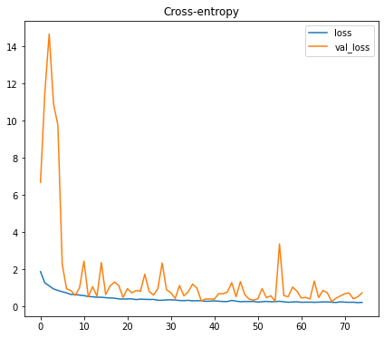

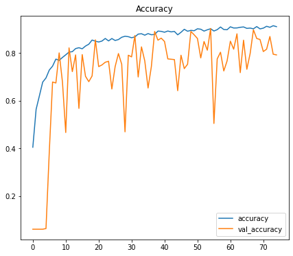

```python
plt.rcParams["figure.figsize"] = (7,6)


history_df.loc[:, ['loss', 'val_loss']].plot(title="Cross-entropy")
history_df.loc[:, ['accuracy', 'val_accuracy']].plot(title="Accuracy")
```

**Observation:**

**Visualize predictions for x_test[2], x_test[3], x_test[33], x_test[36], x_test[59]**

```
Model predicted category for X_test 2 is:  [10]
Actual Category for X_test 2 is:  10
Actual Category Name for X_test 2 is:  Small-flowered Cranesbill
```

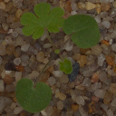

```
--------------------------------------------------------------------------------------------------
Model predicted category for X_test 3 is:  [1]
Actual Category for X_test 3 is:  1
Actual Category Name for X_test 3 is:  Charlock
```

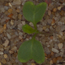

```
--------------------------------------------------------------------------------------------------
Model predicted category for X_test 33 is:  [7]
Actual Category for X_test 33 is:  7
Actual Category Name for X_test 33 is:  Maize
```

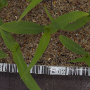

```
--------------------------------------------------------------------------------------------------
Model predicted category for X_test 36 is:  [6]
Actual Category for X_test 36 is:  6
Actual Category Name for X_test 36 is:  Loose Silky-bent
```

[figure not shown]

```
--------------------------------------------------------------------------------------------------
Model predicted category for X_test 59 is:  [2]
Actual Category for X_test 59 is:  2
Actual Category Name for X_test 59 is:  Cleavers
```

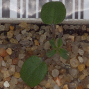

```python
pred_2 = np.argmax(classifier.predict(np.expand_dims(X_test[2],axis=0)),axis=1)
actual_2 = np.argmax(y_test[2])
print("Model predicted category for X_test 2 is: ", pred_2)
print("Actual Category for X_test 2 is: ",actual_2 )
print("Actual Category Name for X_test 2 is: ",categ[actual_2] )
cv2_imshow(X_test[2]*255)
print("\n")
cv2_imshow(X_test_color[2])
print("--------------------------------------------------------------------------------------------------")
pred_3 = np.argmax(classifier.predict(np.expand_dims(X_test[3],axis=0)),axis=1)
actual_3 = np.argmax(y_test[3])
print("Model predicted category for X_test 3 is: ", pred_3)
print("Actual Category for X_test 3 is: ",actual_3 )
print("Actual Category Name for X_test 3 is: ",categ[actual_3] )
cv2_imshow(X_test[3]*255)
print("\n")
cv2_imshow(X_test_color[3])
print("--------------------------------------------------------------------------------------------------")
pred_33 = np.argmax(classifier.predict(np.expand_dims(X_test[33],axis=0)),axis=1)
actual_33 = np.argmax(y_test[33])
print("Model predicted category for X_test 33 is: ", pred_33)
print("Actual Category for X_test 33 is: ",actual_33 )
print("Actual Category Name for X_test 33 is: ",categ[actual_33] )
cv2_imshow(X_test[33]*255)
print("\n")
cv2_imshow(X_test_color[33])
print("--------------------------------------------------------------------------------------------------")
pred_36 = np.argmax(classifier.predict(np.expand_dims(X_test[36],axis=0)),axis=1)
actual_36 = np.argmax(y_test[36])
print("Model predicted category for X_test 36 is: ", pred_36)
print("Actual Category for X_test 36 is: ",actual_36 )
print("Actual Category Name for X_test 36 is: ",categ[actual_36] )
cv2_imshow(X_test[36]*255)
print("\n")
cv2_imshow(X_test_color[36])
print("--------------------------------------------------------------------------------------------------")
pred_59 = np.argmax(classifier.predict(np.expand_dims(X_test[59],axis=0)),axis=1)
actual_59 = np.argmax(y_test[59])
print("Model predicted category for X_test 59 is: ", pred_59)
print("Actual Category for X_test 59 is: ",actual_59 )
print("Actual Category Name for X_test 59 is: ",categ[actual_59] )
cv2_imshow(X_test[59]*255)
print("\n")
cv2_imshow(X_test_color[59])
print("--------------------------------------------------------------------------------------------------")
```

**Observation:**

All the above predictions made by model are equal to Actuals

**Saving Model and Weights**

```python
classifier.save('./classifier_color.h5')                     # save classifier (model) and architecture to single file
classifier.save_weights('./classifier_color_weights.h5')
```

**Conclusion:**

We have built a CNN-model to predict the class of a plant, which works quite well. (Increasing number of epochs and/or adding layers to a model can even increase the performance)

CNN with Batch Normalization, Maxpooling, dropouts + Dense layers is a good combination for image classification

## **Try 2 --> Creating CNN model for Grayscale Images**

**Split the dataset into training, testing, and validation set**

```python
from sklearn.model_selection import train_test_split

val_split = 0.25
#1st split into train and test
X_train, X_test1, y_train, y_test1 = train_test_split(preprocessed_data_gs, ylabels, test_size=0.30, stratify=ylabels,random_state = random_state)
#for my color image purpose and individual image pred.
X_train_color, X_test1_color, y_train_color, y_test1_color = train_test_split(data, ylabels, test_size=0.30, stratify=ylabels,random_state = random_state)
#2nd split into val and test
X_val, X_test, y_val, y_test = train_test_split(X_test1, y_test1, test_size=0.50, stratify=y_test1,random_state = random_state)
#for my color image purpose and individual image pred.
X_val_color, X_test_color, y_val_color, y_test_color = train_test_split(X_test1_color, y_test1, test_size=0.50, stratify=y_test1,random_state = random_state)

X = np.concatenate((X_train, X_test1))
y = np.concatenate((y_train, y_test1))
```

Printing the shapes for all data splits

```python
print("X_train shape: ", X_train.shape)
print("y_train shape: ", y_train.shape)
print("X_val shape: ", X_val.shape)
print("y_val shape: ", y_val.shape)
print("X_test shape: ", X_test.shape)
print("y_test shape: ", y_test.shape)
print("X shape: ", X.shape)
print("y shape: ", y.shape)
```

```
X_train shape:  (3325, 64, 64)
y_train shape:  (3325, 12)
X_val shape:  (712, 64, 64)
y_val shape:  (712, 12)
X_test shape:  (713, 64, 64)
y_test shape:  (713, 12)
X shape:  (4750, 64, 64)
y shape:  (4750, 12)
```

**Observation:**

- X_train has 3325 plant images
- X_val has 712 plant images
- X_test has 713 plant images
- Plan images are in 64X64 shape with grayscale

**Reshaping data into shapes compatible with Keras models**

```python
X_train = X_train.reshape(X_train.shape[0], 64, 64, 1)
X_val = X_val.reshape(X_val.shape[0], 64, 64, 1)
X_test = X_test.reshape(X_test.shape[0], 64, 64, 1)
```

Converting type to float

```python
X_train = X_train.astype('float32')
X_test = X_test.astype('float32')
X_val = X_val.astype('float32')
```

**Using ImageDataGenerator for common data augmentation techniques**

```python
from keras.preprocessing.image import ImageDataGenerator

train_datagen = ImageDataGenerator(shear_range = 0.2,rotation_range=180,  # randomly rotate images in the range
        zoom_range = 0.1, # Randomly zoom image
        width_shift_range=0.1,  # randomly shift images horizontally
        height_shift_range=0.1,  # randomly shift images vertically
        horizontal_flip=True,  # randomly flip images horizontally
        vertical_flip=True  # randomly flip images vertically
    )


# test_val_datagen = ImageDataGenerator(rescale = 1./255)
```

```python
training_set = train_datagen.flow(X_train,y_train,batch_size=batch_size,seed=random_state,shuffle=True)
# val_set = test_val_datagen.flow(X_val,y_val,batch_size=32,seed=random_state,shuffle=True)
# test_set = test_val_datagen.flow(X_test,y_test,batch_size=32,seed=random_state,shuffle=True)
```

**CNN Model building**

```python
# Initialising the CNN classifier1
classifier1 = Sequential()

# Add a Convolution layer with 32 kernels of 3X3 shape with activation function ReLU
classifier1.add(Conv2D(32, (3, 3), input_shape = (64, 64, 1), activation = 'relu', padding = 'same'))
#Adding Batch Normalization
classifier1.add(layers.BatchNormalization())
# Add a Max Pooling layer of size 2X2
classifier1.add(MaxPooling2D(pool_size = (2, 2),strides=2))


# Add another Convolution layer with 32 kernels of 3X3 shape with activation function ReLU
classifier1.add(Conv2D(64, (3, 3), activation = 'relu', padding = 'same'))
classifier1.add(layers.BatchNormalization())
classifier1.add(MaxPooling2D(pool_size = (2, 2),strides=2))

# Add another Convolution layer with 32 kernels of 3X3 shape with activation function ReLU
classifier1.add(Conv2D(64, (3, 3), activation = 'relu', padding = 'valid')) #no Padding
classifier1.add(layers.BatchNormalization())
classifier1.add(MaxPooling2D(pool_size = (2, 2),strides=2))


# Flattening the layer before fully connected layers
classifier1.add(Flatten())

# Adding a fully connected layer with 512 neurons
classifier1.add(layers.BatchNormalization())
classifier1.add(Dense(units = 512, activation = 'elu'))

# Adding dropout with probability 0.2
classifier1.add(Dropout(0.2))


# Adding a fully connected layer with 128 neurons
classifier1.add(layers.BatchNormalization())
classifier1.add(Dense(units = 256, activation = 'elu'))
# classifier1.add(Dropout(0.2))


# The final output layer with 10 neurons to predict the categorical classifcation
classifier1.add(Dense(units = 12, activation = 'softmax'))
```

**Printing the Summary**

```python
classifier1.summary()
```

```
Model: "sequential_1"
_________________________________________________________________
Layer (type)                 Output Shape              Param #
=================================================================
conv2d_3 (Conv2D)            (None, 64, 64, 32)        320
_________________________________________________________________
batch_normalization_5 (Batch (None, 64, 64, 32)        128
_________________________________________________________________
max_pooling2d_3 (MaxPooling2 (None, 32, 32, 32)        0
_________________________________________________________________
conv2d_4 (Conv2D)            (None, 32, 32, 64)        18496
_________________________________________________________________
batch_normalization_6 (Batch (None, 32, 32, 64)        256
_________________________________________________________________
max_pooling2d_4 (MaxPooling2 (None, 16, 16, 64)        0
_________________________________________________________________
conv2d_5 (Conv2D)            (None, 14, 14, 64)        36928
_________________________________________________________________
batch_normalization_7 (Batch (None, 14, 14, 64)        256
_________________________________________________________________
max_pooling2d_5 (MaxPooling2 (None, 7, 7, 64)          0
_________________________________________________________________
flatten_1 (Flatten)          (None, 3136)              0
_________________________________________________________________
batch_normalization_8 (Batch (None, 3136)              12544
_________________________________________________________________
dense_3 (Dense)              (None, 512)               1606144
_________________________________________________________________
dropout_2 (Dropout)          (None, 512)               0
_________________________________________________________________
batch_normalization_9 (Batch (None, 512)               2048
_________________________________________________________________
dense_4 (Dense)              (None, 256)               131328
_________________________________________________________________
dense_5 (Dense)              (None, 12)                3084
=================================================================
Total params: 1,811,532
Trainable params: 1,803,916
Non-trainable params: 7,616
_________________________________________________________________
```

**Compiling and Fitting the model**

```python
# initiate Adam optimizer
adam_opt = optimizers.Adam(learning_rate=0.001, beta_1=0.9, beta_2=0.999, epsilon=1e-08)
classifier1.compile(optimizer = adam_opt, loss = 'categorical_crossentropy', metrics = ['accuracy'])

callback_es = tf.keras.callbacks.EarlyStopping(monitor='val_accuracy', patience=20, min_delta=0.001, restore_best_weights=True)

model2 = classifier1.fit(training_set,
               batch_size=batch_size,
               epochs=epochs,
               validation_data = (X_val,y_val),
               shuffle=True,
               callbacks = [callback_es])
```

**Evaluating on Test data**

```python
classifier1.evaluate(X_test,y_test)
```

```
[0.5521374344825745, 0.8148667812347412]
```

**Best model accuracy from all epochs which has least loss**

```python
best_model_accuracy = model2.history['accuracy'][np.argmin(model2.history['loss'])]
best_model_accuracy
```

```
0.8171428442001343
```

**Observation:**

**Printing out the Confusion Matrix**

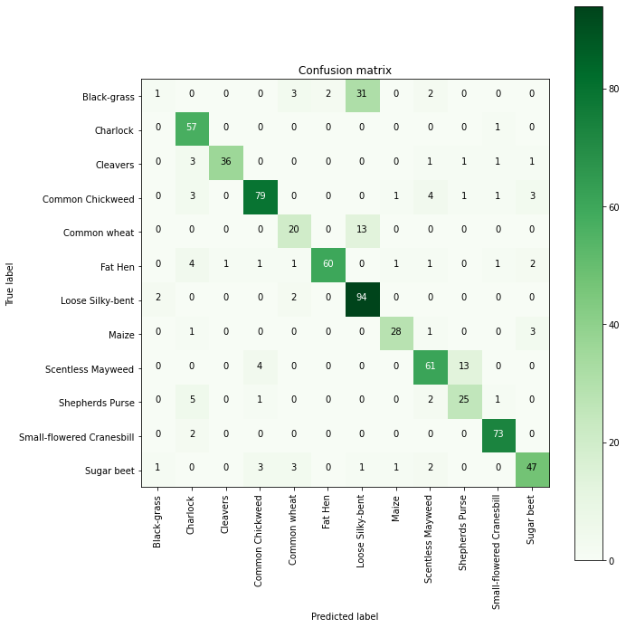

```python
from sklearn.metrics import confusion_matrix
import itertools

def plot_confusion_matrix(cm, classes,
                          normalize=False,
                          title='Confusion matrix',
                          cmap=plt.cm.Greens):

    fig = plt.figure(figsize=(10,10))
    plt.imshow(cm, interpolation='nearest', cmap=cmap)
    plt.title(title)
    plt.colorbar()
    tick_marks = np.arange(len(classes))
    plt.xticks(tick_marks, classes, rotation=90)
    plt.yticks(tick_marks, classes)

    if normalize:
        cm = cm.astype('float') / cm.sum(axis=1)[:, np.newaxis]

    thresh = cm.max() / 2.
    for i, j in itertools.product(range(cm.shape[0]), range(cm.shape[1])):
        plt.text(j, i, cm[i, j],
                 horizontalalignment="center",
                 color="white" if cm[i, j] > thresh else "black")

    plt.tight_layout()
    plt.ylabel('True label')
    plt.xlabel('Predicted label')

# Predict the values from the validation dataset
predY = classifier1.predict(X_test)
predYClasses = np.argmax(predY, axis = 1)
trueY = np.argmax(y_test, axis = 1)

# confusion matrix
confusionMTX = confusion_matrix(trueY, predYClasses)

# plot the confusion matrix
plot_confusion_matrix(confusionMTX, classes = categ)
```

Model did not perform well for:

- Black grass and Loose Silky bent
- Common wheat and loose silky bent
- Shepherds purse and scentless mayweed

**Storing in a DF each epoch's loss and Accuracy for training and validation sets**

```python
history_df2 = pd.DataFrame(model2.history)
history_df2.head()
```

|  | loss | accuracy | val_loss | val_accuracy |
| --- | --- | --- | --- | --- |
| 0 | 2.177024 | 0.327218 | 10.244106 | 0.060393 |
| 1 | 1.627109 | 0.444511 | 13.204697 | 0.060393 |
| 2 | 1.532536 | 0.473383 | 15.499401 | 0.060393 |
| 3 | 1.448261 | 0.490526 | 13.062644 | 0.060393 |
| 4 | 1.319738 | 0.529925 | 7.067779 | 0.071629 |

**Plotting Loss and Accuracy for training and validation sets**

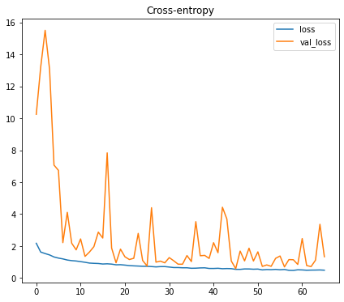

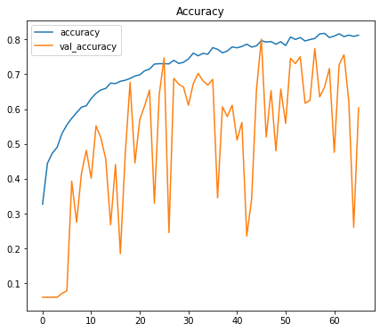

```python
plt.rcParams["figure.figsize"] = (7,6)


history_df2.loc[:, ['loss', 'val_loss']].plot(title="Cross-entropy")
history_df2.loc[:, ['accuracy', 'val_accuracy']].plot(title="Accuracy")
```

**Visualize predictions for x_test[2], x_test[3], x_test[33], x_test[36], x_test[59]**

```
Model predicted category for X_test 2 is:  [10]
Actual Category for X_test 2 is:  10
Actual Category Name for X_test 2 is:  Small-flowered Cranesbill
```

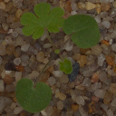

```
--------------------------------------------------------------------------------------------------
Model predicted category for X_test 3 is:  [1]
Actual Category for X_test 3 is:  1
Actual Category Name for X_test 3 is:  Charlock
```

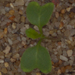

```
--------------------------------------------------------------------------------------------------
Model predicted category for X_test 33 is:  [7]
Actual Category for X_test 33 is:  7
Actual Category Name for X_test 33 is:  Maize
```

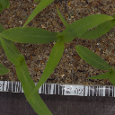

```
--------------------------------------------------------------------------------------------------
Model predicted category for X_test 36 is:  [6]
Actual Category for X_test 36 is:  6
Actual Category Name for X_test 36 is:  Loose Silky-bent
```

[figure not shown]

```
--------------------------------------------------------------------------------------------------
Model predicted category for X_test 59 is:  [2]
Actual Category for X_test 59 is:  2
Actual Category Name for X_test 59 is:  Cleavers
```

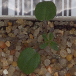

```python
pred_2 = np.argmax(classifier1.predict(np.expand_dims(X_test[2],axis=0)),axis=1)
actual_2 = np.argmax(y_test[2])
print("Model predicted category for X_test 2 is: ", pred_2)
print("Actual Category for X_test 2 is: ",actual_2 )
print("Actual Category Name for X_test 2 is: ",categ[actual_2] )
cv2_imshow(X_test[2]*255)
print("\n")
cv2_imshow(X_test_color[2])
print("--------------------------------------------------------------------------------------------------")
pred_3 = np.argmax(classifier1.predict(np.expand_dims(X_test[3],axis=0)),axis=1)
actual_3 = np.argmax(y_test[3])
print("Model predicted category for X_test 3 is: ", pred_3)
print("Actual Category for X_test 3 is: ",actual_3 )
print("Actual Category Name for X_test 3 is: ",categ[actual_3] )
cv2_imshow(X_test[3]*255)
print("\n")
cv2_imshow(X_test_color[3])
print("--------------------------------------------------------------------------------------------------")
pred_33 = np.argmax(classifier1.predict(np.expand_dims(X_test[33],axis=0)),axis=1)
actual_33 = np.argmax(y_test[33])
print("Model predicted category for X_test 33 is: ", pred_33)
print("Actual Category for X_test 33 is: ",actual_33 )
print("Actual Category Name for X_test 33 is: ",categ[actual_33] )
cv2_imshow(X_test[33]*255)
print("\n")
cv2_imshow(X_test_color[33])
print("--------------------------------------------------------------------------------------------------")
pred_36 = np.argmax(classifier1.predict(np.expand_dims(X_test[36],axis=0)),axis=1)
actual_36 = np.argmax(y_test[36])
print("Model predicted category for X_test 36 is: ", pred_36)
print("Actual Category for X_test 36 is: ",actual_36 )
print("Actual Category Name for X_test 36 is: ",categ[actual_36] )
cv2_imshow(X_test[36]*255)
print("\n")
cv2_imshow(X_test_color[36])
print("--------------------------------------------------------------------------------------------------")
pred_59 = np.argmax(classifier1.predict(np.expand_dims(X_test[59],axis=0)),axis=1)
actual_59 = np.argmax(y_test[59])
print("Model predicted category for X_test 59 is: ", pred_59)
print("Actual Category for X_test 59 is: ",actual_59 )
print("Actual Category Name for X_test 59 is: ",categ[actual_59] )
cv2_imshow(X_test[59]*255)
print("\n")
cv2_imshow(X_test_color[59])
print("--------------------------------------------------------------------------------------------------")
```

All above observations are properly predicted by model

**Storing the model and its weights**

```python
classifier1.save('./classifier_grayscale.h5')                     # save classifier (model) and architecture to single file
classifier1.save_weights('./classifier_grayscale_weights.h5')
```

```python
!ls
```

```
classifier_color.h5	     classifier_grayscale_weights.h5  images.npy
classifier_color_weights.h5  classifier.h5		      Labels.csv
classifier_grayscale.h5      classifier_weights.h5
```

**Conclusion:**

We have built a CNN-model to predict the class of a plant, which works quite well. (Increasing number of epochs and/or adding layers to a model can even increase the performance)

CNN with Batch Normalization, Maxpooling, dropouts + Dense layers is a good combination for image classification